# Japanese assignment

Yitao

2023-03-02

```r
library(tidyverse)
```

```r
library(ggplot2)
```

#Task 4 #What is the square root of 10?

```r
sqrt(10)
```

```
## [1] 3.162278
```

#2. What is the logarithm of 32 to the base 2?

```r
log2(32)
```

```
## [1] 5
```

#3. What is the sum of the numbers from 1 to 1000?

```r
sum(1:1000)
```

```
## [1] 500500
```

#4. What is the sum of all even numbers from 2 to 1000?

```r
sum <- 0
for (i in 2:1000) {
  if (i %% 2 == 0) {
    sum <- sum + i
  }
}
print(sum)
```

```
## [1] 250500
```

```r
choose(100,3)
```

```
## [1] 161700
```

#Task 5 - Using R example datasets

1. Use the R internal CO2 dataset (“data(CO2)”).

```r
data("CO2")
```

#2. Describe briefly the content of the CO2 dataset using the help function.

```r
summary(CO2)
```

```
##      Plant             Type         Treatment       conc          uptake
##  Qn1    : 7   Quebec     :42   nonchilled:42   Min.   :  95   Min.   : 7.70
##  Qn2    : 7   Mississippi:42   chilled   :42   1st Qu.: 175   1st Qu.:17.90
##  Qn3    : 7                                    Median : 350   Median :28.30
##  Qc1    : 7                                    Mean   : 435   Mean   :27.21
##  Qc3    : 7                                    3rd Qu.: 675   3rd Qu.:37.12
##  Qc2    : 7                                    Max.   :1000   Max.   :45.50
##  (Other):42
```

#3. What is the average and median CO2 uptake of the plants from Quebec and Mississippi?

```r
tapply(CO2$uptake, CO2$Type, mean)
```

```
##      Quebec Mississippi
##    33.54286    20.88333
```

```r
tapply(CO2$uptake, CO2$Type, median)
```

```
##      Quebec Mississippi
##       37.15       19.30
```

#Task 6 - R Functions #1. Write a function that calculates the ratio of the mean and the median of a given vector.

```r
meanmedianratio <- function(x) {
  ratio <- mean(x) / median(x)
  return(ratio)
}

meanmedianratio(c(2,3,4,5,6,8,10,20,300))
```

```
## [1] 6.62963
```

#2. Write a function that ignores the lowest and the highest value from a given vector and calculate the mean.

```r
mean.nomaxandmin <- function (vec) {
  sorted_vec <- sort(vec)
   n <- length(sorted_vec)
  ignored_vec <- sorted_vec[2:(n-1)]
  mean(ignored_vec)
}
mean.nomaxandmin(c(2,3,5,8,9))
```

```
## [1] 5.333333
```

The pipe (%>%) is a useful tool for chaining together short sequences of operations in R. However, for longer sequences with many steps, it’s better to use intermediate objects with meaningful names for easier debugging and to communicate intent. Additionally, if you have multiple inputs or outputs or a complex dependency structure, it’s best not to use pipes, as they are fundamentally linear and may result in confusing code.

#4. Familiarize yourself with the apply-family of functions (apply, lapply, sapply etc.)http://uc-r.github.io/apply_family, Write a short explanation (max. 300 characters, no spaces) of why they could be useful in your work.

The apply-family functions in R, such as apply(), sapply(), and lapply(), can assist in bioinformatic analysis by enabling efficient and automated processing of large datasets. These functions allow for the application of a function to subsets of data, matrices, or arrays, making it easier to analyze and manipulate complex biological data.

# Task 7 - Basic visualization with R

# 1.1. Compare the distributions of the body heights of the two species from the ‘magic_guys.csv’ dataset graphically

```r
library(remotes)
magic_guys <- read.csv("magic_guys.csv")
head(magic_guys)
```

```
##   uniqId species length weight
## 1     p1    jedi  174.6   71.3
## 2     p2    jedi  252.2   70.8
## 3     p3    jedi  229.8   70.7
## 4     p4    jedi  176.2   80.4
## 5     p5    jedi  213.3   82.0
## 6     p6    jedi  112.5   64.2
```

#a. using the basic ‘hist’ function as well as ‘ggplot’ and ‘geom_histogram’ functions from the ggplot2 package. Optimize the plots for example by trying several different ‘breaks’. Note that ggplot2-based functions give you many more options for changing the visualization parameters, try some of them.

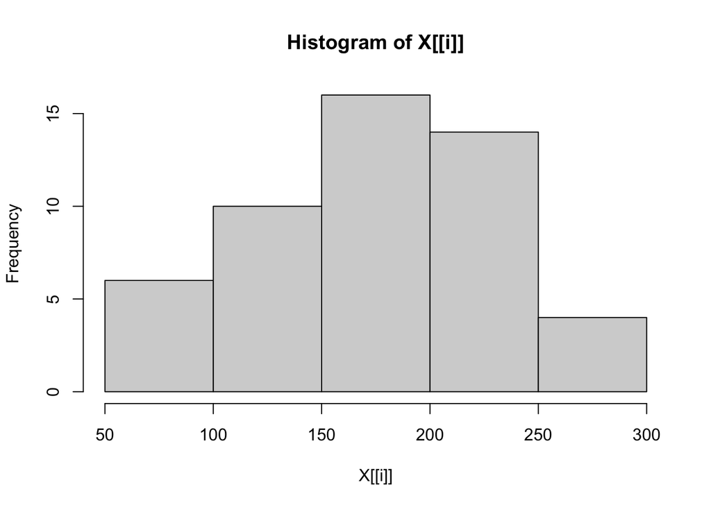

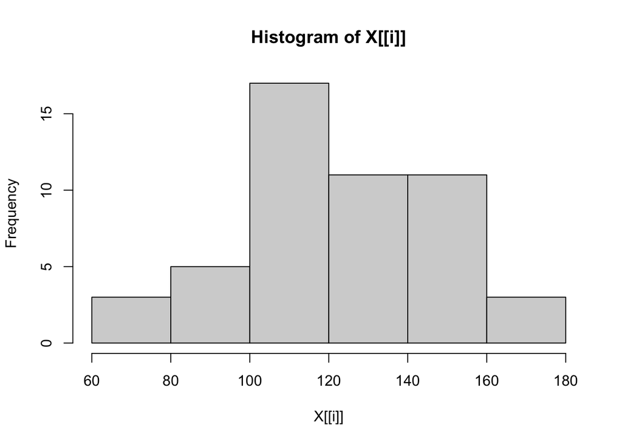

```
## $jedi
## $breaks
## [1]  50 100 150 200 250 300
##
## $counts
## [1]  6 10 16 14  4
##
## $density
## [1] 0.0024 0.0040 0.0064 0.0056 0.0016
##
## $mids
## [1]  75 125 175 225 275
##
## $xname
## [1] "X[[i]]"
##
## $equidist
## [1] TRUE
##
## attr(,"class")
## [1] "histogram"
##
## $sith
## $breaks
## [1]  60  80 100 120 140 160 180
##
## $counts
## [1]  3  5 17 11 11  3
##
## $density
## [1] 0.003 0.005 0.017 0.011 0.011 0.003
##
## $mids
## [1]  70  90 110 130 150 170
##
## $xname
## [1] "X[[i]]"
##
## $equidist
## [1] TRUE
##
## attr(,"class")
## [1] "histogram"
```

```r
tapply(magic_guys$length, magic_guys$species, hist)
```

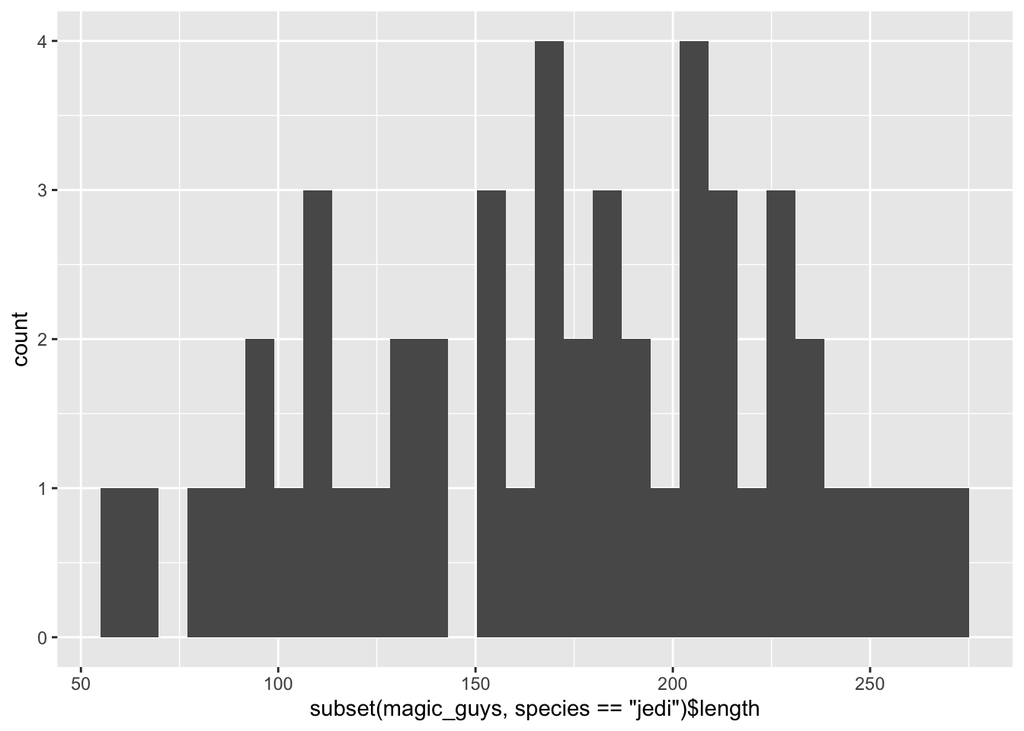

```r
j.length <- as.data.frame(subset(magic_guys, species == "jedi")$length)
s.length <- as.data.frame(subset(magic_guys, species == "sith")$length)

ggplot(j.length, aes(x = subset(magic_guys, species == "jedi")$length)) + geom_histogram()
```

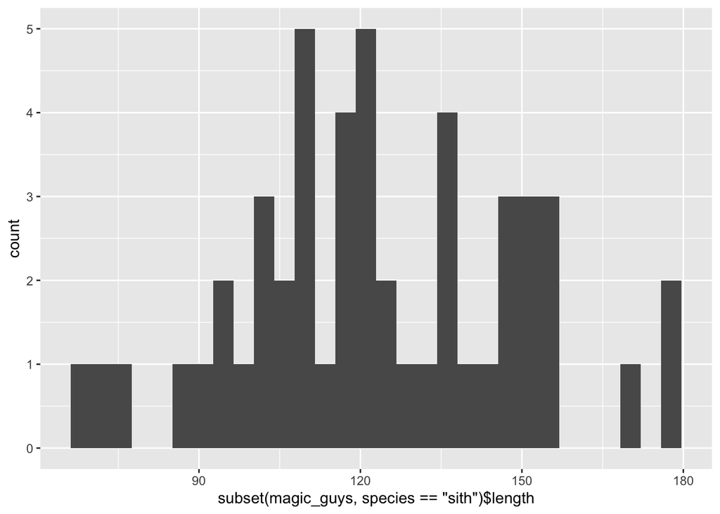

```r
ggplot(s.length, aes(x = subset(magic_guys, species == "sith")$length)) + geom_histogram()
```

#b. Do the same comparison as in a. but with boxplots. If you want to use the ggplot2-package, use the functions ‘ggplot’ and ‘geom_boxplot’.

```r
png("boxplot.png")
pdf("boxplot.png")
svg("boxplot.png")
ggplot(magic_guys, aes(y = length, group=species)) +
 geom_boxplot()

dev.off()
```

#c. Save the plots with the ‘png’, ‘pdf’, and ‘svg’ formats. In which situation would you use which file format? If one needs a high-quality image for printing or publication, PDF may be the best choice. If one needs an image for the web or for interactive purposes, SVG may be a better choice. If one needs a small, portable image for sharing or embedding, PNG may be a good choice.

#2. Load the gene expression data matrix from the ‘microarray_data.tab’ dataset provided in the shared folder, it is a big tabular separated matrix.

```r
array <- read.table("microarray_data.tab", sep="\t", header=TRUE)
```

#a. How big is the matrix in terms of rows and columns?

```r
dim(array)
```

```
## [1]  553 1000
```

#b. Count the missing values per gene and visualize this result.

```r
missing_values <- colSums(is.na(array))

print(missing_values)
```

```
##    g1    g2    g3    g4    g5    g6    g7    g8    g9   g10   g11   g12   g13
##   130   104    74    93    81    30    31    26    12    56    72   105    55
##   g14   g15   g16   g17   g18   g19   g20   g21   g22   g23   g24   g25   g26
##   133    75    67    21   553    13     9   207   190    96   141   122   149
##   g27   g28   g29   g30   g31   g32   g33   g34   g35   g36   g37   g38   g39
##    47    59   210    22    14    52    14    24    70    83    64    91   144
##   g40   g41   g42   g43   g44   g45   g46   g47   g48   g49   g50   g51   g52
##   124   216    64    13    70    61   108    68   404   106    91   230   231
##   g53   g54   g55   g56   g57   g58   g59   g60   g61   g62   g63   g64   g65
##   207   195   553   196   186   553   224   362   198   217   208   210   188
##   g66   g67   g68   g69   g70   g71   g72   g73   g74   g75   g76   g77   g78
##   351   187   189   187   194   185   185   354   203   216   216   245   201
##   g79   g80   g81   g82   g83   g84   g85   g86   g87   g88   g89   g90   g91
##   553   189   188   224   553   213   188   194   192   213   219   229   365
##   g92   g93   g94   g95   g96   g97   g98   g99  g100  g101  g102  g103  g104
##   223   369   353   195   230   250   238   553   204   228   199   192   211
##  g105  g106  g107  g108  g109  g110  g111  g112  g113  g114  g115  g116  g117
##   373   251   261   207   362   187   200   209   210   224   203   205   189
##  g118  g119  g120  g121  g122  g123  g124  g125  g126  g127  g128  g129  g130
##   212   236   260    33    26    25    22    14    48    36    42    18   194
##  g131  g132  g133  g134  g135  g136  g137  g138  g139  g140  g141  g142  g143
##   213   367   198   199   553   185   553   553   191   186    14   177     8
##  g144  g145  g146  g147  g148  g149  g150  g151  g152  g153  g154  g155  g156
##    13    17     8   186   202    21    30   198   186   207   185   188   196
##  g157  g158  g159  g160  g161  g162  g163  g164  g165  g166  g167  g168  g169
##   215   186   188   187    36    27    28    18   212    36     8    23    33
##  g170  g171  g172  g173  g174  g175  g176  g177  g178  g179  g180  g181  g182
##    23   226   376   200   215   193   214   185   224   203   193    10     9
##  g183  g184  g185  g186  g187  g188  g189  g190  g191  g192  g193  g194  g195
##    10    18    32    47    31    44    15    20    36    35    36    61    20
##  g196  g197  g198  g199  g200  g201  g202  g203  g204  g205  g206  g207  g208
##   188    12     8    12   187    12     7    19   215    15    12     8    11
##  g209  g210  g211  g212  g213  g214  g215  g216  g217  g218  g219  g220  g221
##    23   173     9    14     7    29    15    36    15    10    16    10    56
##  g222  g223  g224  g225  g226  g227  g228  g229  g230  g231  g232  g233  g234
##    31    83    52    27    27    12    13    38    44    17    24   188    11
##  g235  g236  g237  g238  g239  g240  g241  g242  g243  g244  g245  g246  g247
##    36    30    39    55    64    38    81    66    65    61    24    26    47
##  g248  g249  g250  g251  g252  g253  g254  g255  g256  g257  g258  g259  g260
##    26    36    23    47   203     2    20    17     8     7    70    34   392
```

[output cut: 99 more lines]

```
##   393   244   225    11    19    85    35    15    35    35    34   108   191
##  g911  g912  g913  g914  g915  g916  g917  g918  g919  g920  g921  g922  g923
##    79    30    20    19    52    15    30    35   553    34    48    71    28
##  g924  g925  g926  g927  g928  g929  g930  g931  g932  g933  g934  g935  g936
##    55    44   192    19    10    30    26   185   376   224   232   192   250
##  g937  g938  g939  g940  g941  g942  g943  g944  g945  g946  g947  g948  g949
##   217   202   228   199    18    17    22    10    70    32   199    69    36
##  g950  g951  g952  g953  g954  g955  g956  g957  g958  g959  g960  g961  g962
##    13   187    57    31    12    21    68    26    26    16    19    14    53
##  g963  g964  g965  g966  g967  g968  g969  g970  g971  g972  g973  g974  g975
##    56    20    83    10    11    14    26   191   553   225   228   222   211
##  g976  g977  g978  g979  g980  g981  g982  g983  g984  g985  g986  g987  g988
##   227   184   195   205   354    11    50    10    32   188    13    13    14
##  g989  g990  g991  g992  g993  g994  g995  g996  g997  g998  g999 g1000
##   201    21    13    13    20    29    12    33    18    19    24    17
```

3. Find the genes for which there are more than X% (X=10%, 20%, 50%) missing values.

```r
missing_percent <- colMeans(is.na(array)) * 100

# Find the genes with more than 10%, 20%, and 50% missing values
genes_10percent <- names(missing_percent[missing_percent > 10])
genes_20percent <- names(missing_percent[missing_percent > 20])
genes_50percent <- names(missing_percent[missing_percent > 50])

# Print the result
cat("Genes with more than 10% missing values:", genes_10percent, "\n")
```

```
## Genes with more than 10% missing values: g1 g2 g3 g4 g5 g10 g11 g12 g14 g15 g16 g18 g21 g22 g23 g24 g25 g26 g28 g29 g35 g36 g37 g38 g39 g40 g41 g42 g44 g45 g46 g47 g48 g49 g50 g51 g52 g53 g54 g55 g56 g57 g58 g59 g60 g61 g62 g63 g64 g65 g66 g67 g68 g69 g70 g71 g72 g73 g74 g75 g76 g77 g78 g79 g80 g…
```

```r
cat("Genes with more than 20% missing values:", genes_20percent, "\n")
```

```
## Genes with more than 20% missing values: g1 g14 g18 g21 g22 g24 g25 g26 g29 g39 g40 g41 g48 g51 g52 g53 g54 g55 g56 g57 g58 g59 g60 g61 g62 g63 g64 g65 g66 g67 g68 g69 g70 g71 g72 g73 g74 g75 g76 g77 g78 g79 g80 g81 g82 g83 g84 g85 g86 g87 g88 g89 g90 g91 g92 g93 g94 g95 g96 g97 g98 g99 g100 g101…
```

```r
cat("Genes with more than 50% missing values:", genes_50percent, "\n")
```

```
## Genes with more than 50% missing values: g18 g48 g55 g58 g60 g66 g73 g79 g83 g91 g93 g94 g99 g105 g109 g132 g135 g137 g138 g172 g260 g290 g301 g329 g352 g355 g362 g363 g368 g383 g388 g389 g390 g391 g406 g417 g431 g432 g440 g461 g462 g498 g519 g527 g531 g532 g538 g572 g575 g576 g577 g585 g615 g619…
```

4. Replace the missing values by the average expression value for the particular gene. (Note: Imputing data has to be used with caution!)

```r
array.new <- apply(array, 2, function(x) replace(x, is.na(x), mean(x, na.rm = TRUE)))
```

#3. Visualize the data in the CO2 dataset in a way that gives you a deeper understanding of the data. What do you see? Chilling treatment will lower the uptake of CO2, especially in Mississippi, but it has no significant effect on CO2 concentration.

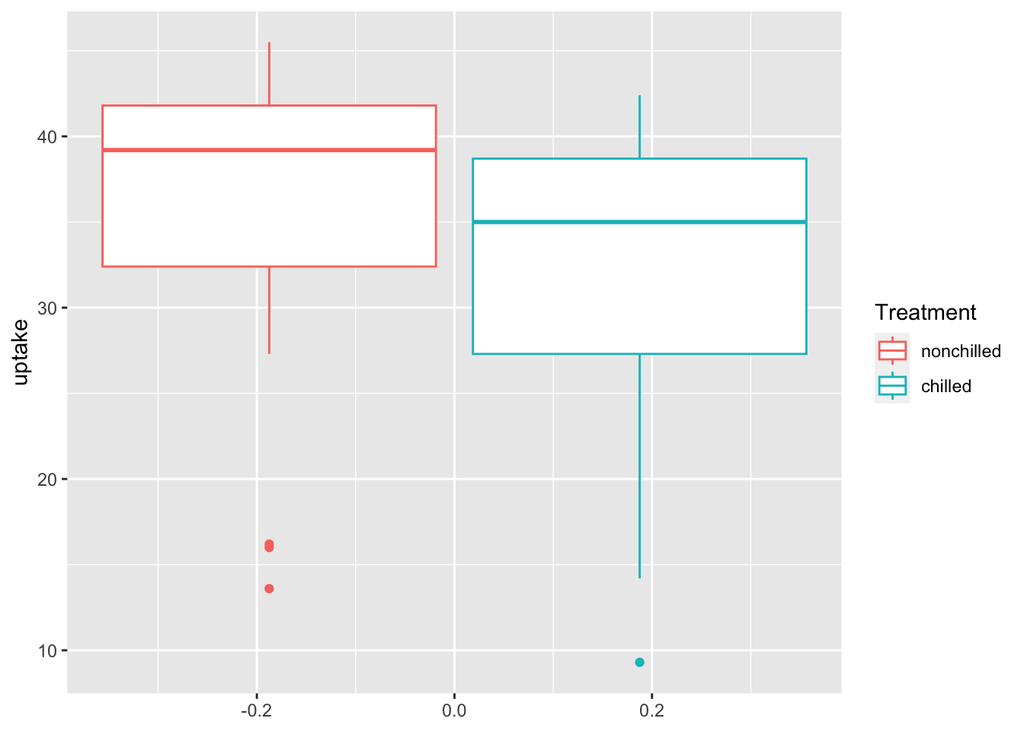

```r
ggplot (subset(CO2, Type=="Quebec"), aes(y=uptake,  color=Treatment)) + geom_boxplot()
```

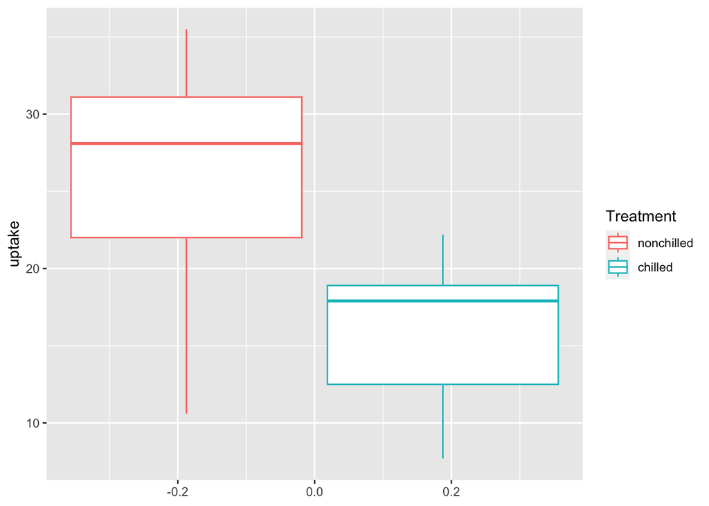

```r
ggplot (subset(CO2, Type=="Mississippi"), aes(y=uptake,  color=Treatment)) + geom_boxplot()
```

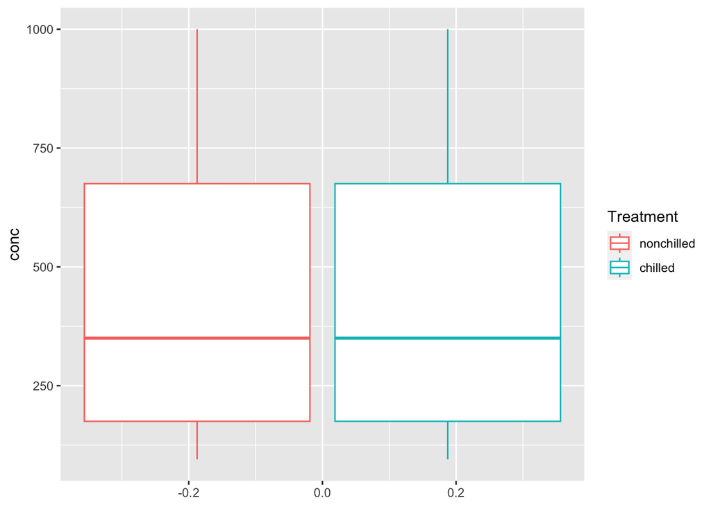

```r
ggplot (subset(CO2, Type=="Quebec"), aes(y=conc,  color=Treatment)) + geom_boxplot()
```

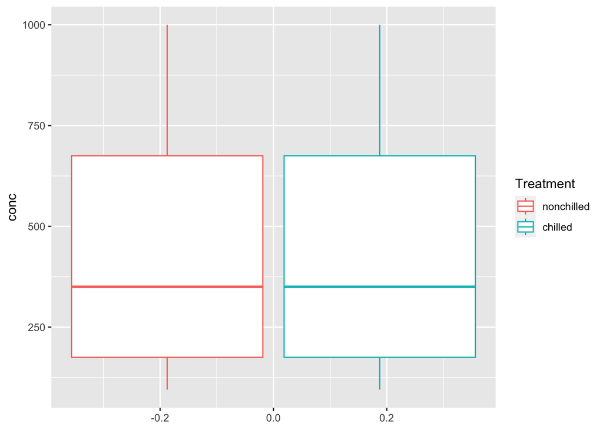

```r
ggplot (subset(CO2, Type=="Mississippi"), aes(y=conc,  color=Treatment)) + geom_boxplot()
```

#Task 8

#1. Install the Tidybiology package, which includes the data ‘chromosome’ and ‘proteins’

```r
library(devtools)
devtools::install_github("hirscheylab/tidybiology")
force=TRUE
library(tidybiology)
```

#a. Extract summary statistics (mean, median and maximum) for the following variables from the ‘chromosome’ data: variations, protein coding genes, and miRNAs. Utilize the tidyverse functions to make this as simply as possible.

```r
summary(chromosome$variations)
```

```
##     Min.  1st Qu.   Median     Mean  3rd Qu.     Max.
##   211643  4395298  6172346  6484572  8742592 12945965
```

```r
summary(chromosome$protein_codinggenes)
```

```
##    Min. 1st Qu.  Median    Mean 3rd Qu.    Max.
##    71.0   595.8   836.0   850.0  1055.5  2058.0
```

```r
summary(chromosome$mi_rna)
```

```
##    Min. 1st Qu.  Median    Mean 3rd Qu.    Max.
##   15.00   55.75   75.00   73.17   92.00  134.00
```

```r
summary(chromosome)
```

```
##        id       length_mm       basepairs           variations
##  1      : 1   Min.   :16.00   Min.   : 46709983   Min.   :  211643
##  2      : 1   1st Qu.:27.75   1st Qu.: 82536402   1st Qu.: 4395298
##  3      : 1   Median :45.50   Median :133536366   Median : 6172346
##  4      : 1   Mean   :43.83   Mean   :128677910   Mean   : 6484572
##  5      : 1   3rd Qu.:55.00   3rd Qu.:162210974   3rd Qu.: 8742592
##  6      : 1   Max.   :85.00   Max.   :248956422   Max.   :12945965
##  (Other):18
##  protein_codinggenes  pseudo_genes    totallongnc_rna  totalsmallnc_rna
##  Min.   :  71.0      Min.   : 185.0   Min.   :  71.0   Min.   : 30.0
##  1st Qu.: 595.8      1st Qu.: 445.8   1st Qu.: 439.0   1st Qu.:167.0
##  Median : 836.0      Median : 590.5   Median : 633.5   Median :220.5
##  Mean   : 850.0      Mean   : 608.3   Mean   : 613.6   Mean   :208.9
##  3rd Qu.:1055.5      3rd Qu.: 772.5   3rd Qu.: 751.0   3rd Qu.:236.0
##  Max.   :2058.0      Max.   :1220.0   Max.   :1200.0   Max.   :496.0
##
##      mi_rna           r_rna           sn_rna          sno_rna
##  Min.   : 15.00   Min.   : 5.00   Min.   : 17.00   Min.   :  3.00
##  1st Qu.: 55.75   1st Qu.:13.00   1st Qu.: 49.75   1st Qu.: 36.75
##  Median : 75.00   Median :23.00   Median : 77.00   Median : 59.50
##  Mean   : 73.17   Mean   :22.08   Mean   : 81.00   Mean   : 63.38
##  3rd Qu.: 92.00   3rd Qu.:27.25   3rd Qu.:106.00   3rd Qu.: 76.00
##  Max.   :134.00   Max.   :66.00   Max.   :221.00   Max.   :145.00
##
##    miscnc_rna     centromereposition_mbp
##  Min.   :  8.00   Min.   : 12.50
##  1st Qu.: 66.50   1st Qu.: 18.73
##  Median : 94.50   Median : 38.40
##  Mean   : 92.21   Mean   : 43.36
##  3rd Qu.:107.50   3rd Qu.: 55.25
##  Max.   :192.00   Max.   :125.00
##
```

#b. How does the chromosome size distribute? Plot a graph that helps to visualize this by using ggplot2 package functions.

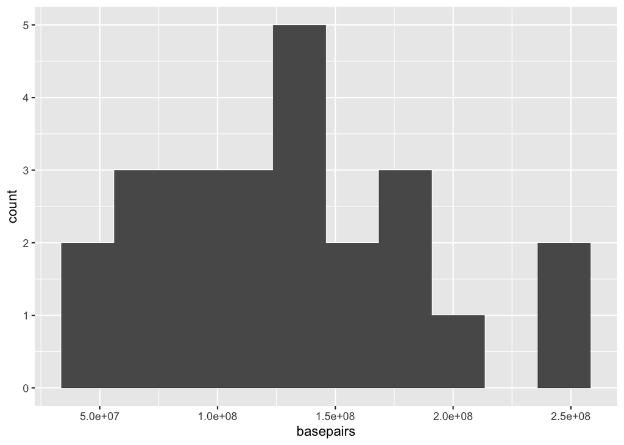

```r
ggplot(chromosome, aes(x=basepairs)) + geom_histogram(bins = 10)
```

#c. Does the number of protein coding genes or miRNAs correlate with the length of the chromosome? Make two separate plots to visualize these relationships. It seems miRNA correlates more than the length of chromosome with number of protein coding genes.

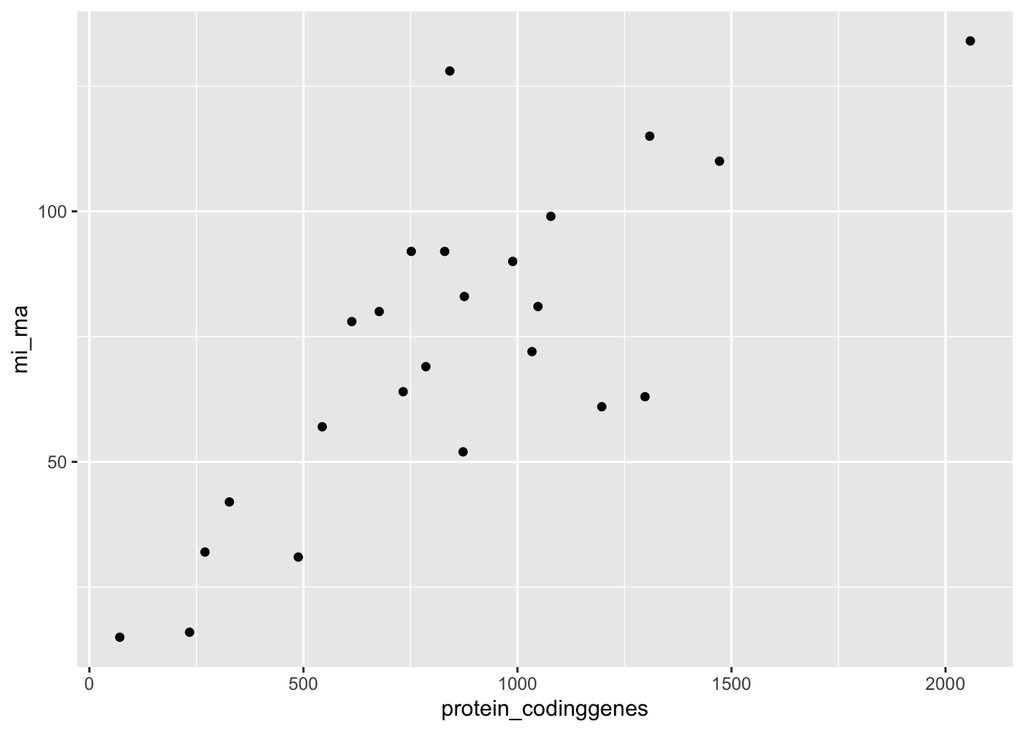

```r
ggplot(chromosome, aes(x=protein_codinggenes, y=mi_rna)) + geom_point()
```

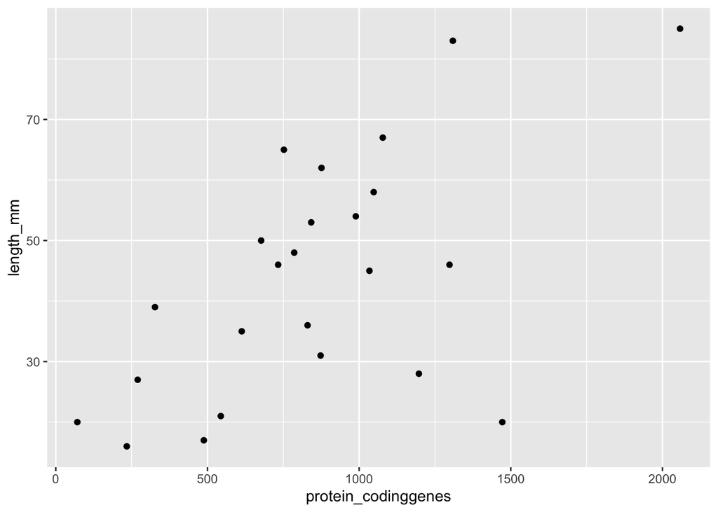

```r
ggplot(chromosome, aes(x=protein_codinggenes, y=length_mm)) + geom_point()
```

#d. Calculate the same summary statistics for the ‘proteins’ data variables length and mass. Create a meaningful visualization of the relationship between these two variables by utilizing the ggplot2 package functions. Play with the colors, theme- and other visualization parameters to create a plot that pleases you.

```r
summary(proteins$length)
```

```
##    Min. 1st Qu.  Median    Mean 3rd Qu.    Max.
##     2.0   251.0   414.0   557.2   669.0 34350.0
```

```r
summary(proteins$mass)
```

```
##    Min. 1st Qu.  Median    Mean 3rd Qu.    Max.
##     260   27940   46140   62061   74755 3816030
```

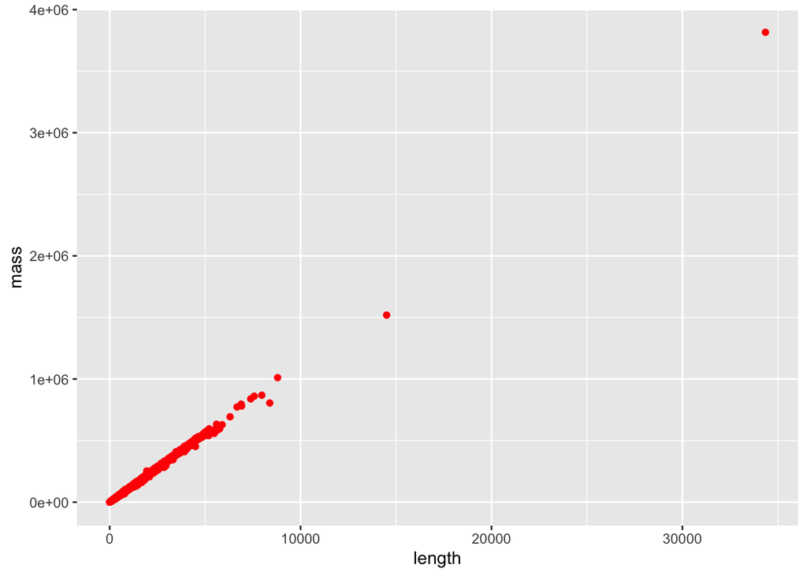

```r
?ggplot()
ggplot(proteins, aes(x=length, y=mass)) + geom_point(color="red")
```